# Practical Machine Learning Project

Micaela

August 18, 2015

### Overview

The goal of the present analyses is to build a machine learning model that is able to predict, based on on-body sensor data, whether a participant did a bicep curl correctly (Class A), threw their elbows out in front (Class B), lifted the dumbbel only halfway (Class C), lowered the dumbbell halfway (Class D), or threw their hips to the front (Class E). The reference for the training data is listed below. The training data includes data from six participants who had sensors placed on their forearms, arms, belt, and dumbbells while they did 10 bicep curls from each of the five different classes.

Reference for the data: Velloso, E.; Bulling, A.; Gellersen, H.; Ugulino, W.; Fuks, H. Qualitative Activity Recognition of Weight Lifting Exercises. Proceedings of 4th International Conference in Cooperation with SIGCHI (Augmented Human ’13) . Stuttgart, Germany: ACM SIGCHI, 2013.

Read more: http://groupware.les.inf.puc-rio.br/har#ixzz3jCsPudr4

### Step 1. Read in Data

```r
if(!file.exists("./data")){dir.create("./data")}
URL1 <- "https://d396qusza40orc.cloudfront.net/predmachlearn/pml-training.csv"
URL2 <- "https://d396qusza40orc.cloudfront.net/predmachlearn/pml-testing.csv" #this is the data to use for the course submission
download.file(URL1,"./data/training", method="curl")
download.file(URL2, "./data/testing", method="curl")
(dateDownloaded <- date())
```

```
## [1] "Wed Aug 19 23:17:52 2015"
```

```r
train_data <- read.csv("./data/training")
test_data <- read.csv("./data/testing") #Not used in current analyses- used in submission part of course project
```

### Step 2. Create Training and Testing Datasets

```r
library(caret)
inTrain <- createDataPartition(y=train_data$classe, p=.7, list=FALSE) #Data split into training (70%) and testing (30%)
training <- train_data[inTrain,]
testing <- train_data[-inTrain,]
```

### Step 3. Pick Features

Before picking features, let’s look at the variables in the dataset and remove any variables that could be problematic due to missing values.

```r
summary(training) #the training data has many variables with missing data

#Remove columns with all of their data missing:
na_col <- NULL
for (i in 1:ncol(training)){
  na_col[i] <- sum(is.na(training[,i]))
  }
training <- training[,names(training)[na_col==0]]

#Remove "bookkeeping variables"
subset <- training[,-(1:7)] #remove all bookkeeping variables
summary(subset) #There are still a lot of variables with most of their values missing

#Remove columns that have the majority of their data missing
remove <- NULL
#remove all variables with kurtosis, skewness, max, min, and amplitude in their names- they have large amounts of missing data
for (i in c("kurtosis", "skewness", "max", "min","amplitude")){
  remove <- c(remove, grep(paste("^",i,".",sep=""),names(subset)))
  }
subset <- subset[,-remove]
```

### Step 4. Run Prediction Models

Since we are trying to predict a categorical variable (class), it makes sense to start with a classification tree algorithm (using 10-fold cross validation).

```r
set.seed(1234)
ctrl <- trainControl(method="cv",savePred=T)
modelFit1 <- train(classe~.,data=subset, method="rpart", trControl=ctrl)
modelFit1$finalModel
```

```
## n= 13737
##
## node), split, n, loss, yval, (yprob)
##       * denotes terminal node
##
##  1) root 13737 9831 A (0.28 0.19 0.17 0.16 0.18)
##    2) roll_belt< 130.5 12584 8685 A (0.31 0.21 0.19 0.18 0.11)
##      4) pitch_forearm< -34.55 1096    2 A (1 0.0018 0 0 0) *
##      5) pitch_forearm>=-34.55 11488 8683 A (0.24 0.23 0.21 0.2 0.12)
##       10) magnet_dumbbell_y< 439.5 9731 6981 A (0.28 0.18 0.24 0.19 0.11)
##         20) roll_forearm< 122.5 6002 3549 A (0.41 0.18 0.18 0.17 0.061) *
##         21) roll_forearm>=122.5 3729 2511 C (0.08 0.18 0.33 0.23 0.18) *
##       11) magnet_dumbbell_y>=439.5 1757  859 B (0.031 0.51 0.042 0.23 0.19) *
##    3) roll_belt>=130.5 1153    7 E (0.0061 0 0 0 0.99) *
```

```r
modelFit1
```

```
## CART
##
## 13737 samples
##    52 predictor
##     5 classes: 'A', 'B', 'C', 'D', 'E'
##
## No pre-processing
## Resampling: Cross-Validated (10 fold)
##
## Summary of sample sizes: 12365, 12363, 12364, 12364, 12362, 12362, ...
##
## Resampling results across tuning parameters:
##
##   cp          Accuracy   Kappa       Accuracy SD  Kappa SD
##   0.03509307  0.5119762  0.36305886  0.01940229   0.02564250
##   0.05981080  0.4273715  0.22837986  0.06530126   0.11031370
##   0.11585800  0.3155684  0.04757811  0.04037397   0.06161794
##
## Accuracy was used to select the optimal model using  the largest value.
## The final value used for the model was cp = 0.03509307.
```

The accuracy of Model 1 was only around 50%. To improve accuracy, let’s fit the same features to a random forest model.

```r
modelFit2 <- train(classe~.,data=subset, method="rf", importance=TRUE, trControl=ctrl)
modelFit2$finalModel
```

```
##
## Call:
##  randomForest(x = x, y = y, mtry = param$mtry, importance = TRUE)
##                Type of random forest: classification
##                      Number of trees: 500
## No. of variables tried at each split: 27
##
##         OOB estimate of  error rate: 0.74%
## Confusion matrix:
##      A    B    C    D    E class.error
## A 3902    2    2    0    0 0.001024066
## B   20 2630    8    0    0 0.010534236
## C    0   13 2372   11    0 0.010016694
## D    0    1   30 2218    3 0.015097691
## E    0    1    3    7 2514 0.004356436
```

```r
modelFit2
```

```
## Random Forest
##
## 13737 samples
##    52 predictor
##     5 classes: 'A', 'B', 'C', 'D', 'E'
##
## No pre-processing
## Resampling: Cross-Validated (10 fold)
##
## Summary of sample sizes: 12363, 12364, 12364, 12363, 12362, 12363, ...
##
## Resampling results across tuning parameters:
##
##   mtry  Accuracy   Kappa      Accuracy SD  Kappa SD
##    2    0.9916285  0.9894093  0.002573354  0.003256536
##   27    0.9922840  0.9902392  0.002993948  0.003787141
##   52    0.9882074  0.9850810  0.003158010  0.003996319
##
## Accuracy was used to select the optimal model using  the largest value.
## The final value used for the model was mtry = 27.
```

Now accuracy is very good (99%). Estimates of out-of-sample error rates from the 10-fold cross validation are nearly zero. Comparing the accuracy between the classification tree model (Model1) and the random forest model (Model2) using the resamples function confirms the superior accuracy of Model2.

```r
resamps <- resamples(list(
model1 = modelFit1,
model2 = modelFit2))

summary(resamps)
```

```
##
## Call:
## summary.resamples(object = resamps)
##
## Models: model1, model2
## Number of resamples: 10
##
## Accuracy
##          Min. 1st Qu. Median   Mean 3rd Qu.   Max. NA's
## model1 0.4756  0.5051 0.5193 0.5120  0.5220 0.5415    0
## model2 0.9876  0.9900 0.9931 0.9923  0.9947 0.9956    0
##
## Kappa
##          Min. 1st Qu. Median   Mean 3rd Qu.   Max. NA's
## model1 0.3158  0.3542 0.3724 0.3631  0.3764 0.4028    0
## model2 0.9844  0.9873 0.9912 0.9902  0.9933 0.9945    0
```

Given that both models included 52 features, it is interesting to look at which features are most important for accurate prediction.

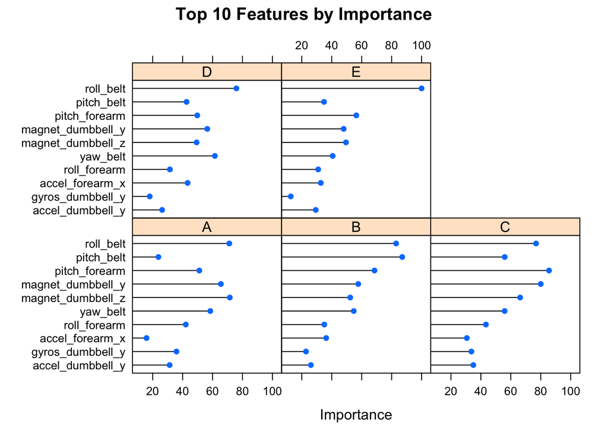

### Step 5. Apply the Best-Fitting Model to Test Data

First all of the preprocessing steps used in the training data need to be repeated (removing bookkeeping variables and variables with large numbers of missing data)

```r
testing <- testing[,names(testing)[na_col==0]]
subset_test <- testing[,-(1:7)] #remove all bookkeeping variables
subset_test <- subset_test[,-remove]
```

Now Model2 is fit to the 30% of the original dataset that was removed and became the test set.

```r
predictions <- predict(modelFit2,subset_test)
confusionMatrix(predictions,subset_test$classe)
```

```
## Confusion Matrix and Statistics
##
##           Reference
## Prediction    A    B    C    D    E
##          A 1673    6    0    0    0
##          B    0 1133    1    0    0
##          C    0    0 1023    6    1
##          D    0    0    2  957    1
##          E    1    0    0    1 1080
##
## Overall Statistics
##
##                Accuracy : 0.9968
##                  95% CI : (0.995, 0.9981)
##     No Information Rate : 0.2845
##     P-Value [Acc > NIR] : < 2.2e-16
##
##                   Kappa : 0.9959
##  Mcnemar's Test P-Value : NA
##
## Statistics by Class:
##
##                      Class: A Class: B Class: C Class: D Class: E
## Sensitivity            0.9994   0.9947   0.9971   0.9927   0.9982
## Specificity            0.9986   0.9998   0.9986   0.9994   0.9996
## Pos Pred Value         0.9964   0.9991   0.9932   0.9969   0.9982
## Neg Pred Value         0.9998   0.9987   0.9994   0.9986   0.9996
## Prevalence             0.2845   0.1935   0.1743   0.1638   0.1839
## Detection Rate         0.2843   0.1925   0.1738   0.1626   0.1835
## Detection Prevalence   0.2853   0.1927   0.1750   0.1631   0.1839
## Balanced Accuracy      0.9990   0.9973   0.9978   0.9961   0.9989
```

The fit in the testing data is also very good, with accuracy at 99% and out-of-sample error rate estimates less than 1%.